# R Notebook

Source of this exercise: http://blog.revolutionanalytics.com/2014/01/quantitative-finance-applications-in-r-plotting-xts-time-series.html

# Data Fetching

To start, let’s look at five sets of cumulative returns for the following ETF’s:

[SPY SPDR S&P 500 ETF Trust](https://www.google.com/finance?cid=700145)

[QQQ PowerShares NASDAQ QQQ Trust](https://www.google.com/finance?q=NASDAQ%3AQQQ&ei=ddbeUuqkILK0iAL8xwE)

[GDX Market Vectors Gold Miners ETF](https://www.google.com/finance?q=NYSEARCA%3AGDX&ei=pdbeUtGXJ6qtiAKeggE)

[DBO PowerShares DB Oil Fund (ETF)](https://www.google.com/finance?q=NYSEARCA%3ADBO&ei=49beUvD6OqqtiAKeggE)

[VWO Vanguard FTSE Emerging Markets ETF](https://www.google.com/finance?q=vwo&ei=JtfeUrjMGKqtiAKeggE)

Extract the data using quantmod

```
## [1] "SPY" "QQQ" "GDX" "DBO" "VWO"
```

Create the cumulative returns by dividing by the first price.

Now merge the XTS objects back into one.

```
##            SPY.Close QQQ.Close GDX.Close DBO.Close VWO.Close
## 2007-01-03 1.0000000  1.000000 1.0000000 1.0000000 1.0000000
## 2007-01-04 1.0021221  1.018964 0.9815249 1.0000000 0.9890886
## 2007-01-05 0.9941289  1.014107 0.9682539 1.0000000 0.9614891
## 2007-01-08 0.9987268  1.014801 0.9705959 1.0024722 0.9720154
## 2007-01-09 0.9978780  1.019889 0.9640905 0.9929955 0.9487805
## 2007-01-10 1.0012025  1.031915 0.9526412 0.9517923 0.9460847
```

In this case the merge() produces the union of all dates, and fills NAs by default. There were two NAs, so I just filled them with 1 since they were in the beg of the series.

# Plotting

## Zoo plot(.)

We will now look how we can plot all five series, overlayed on a single graph. In particular, we will look at the plot(.) functions in both the zoo and xts packages. The plot(.) function provided in zoo is very simple to use, as we can use the whole zoo.basket object as input, and the plot(.) function will overlay the time series and scale the vertical axis for us with the help of a single parameter setting, namely the screens parameter.

*Last, but crucial, is the parameter setting screens = 1, which tells the plot command to overlay each series in a single graph.*

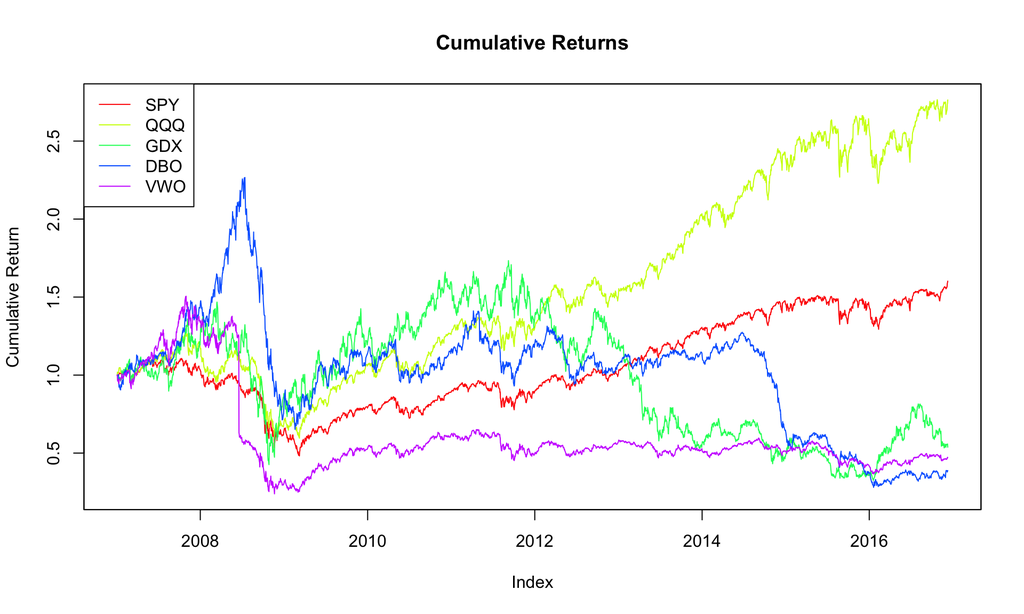

### With custom colors

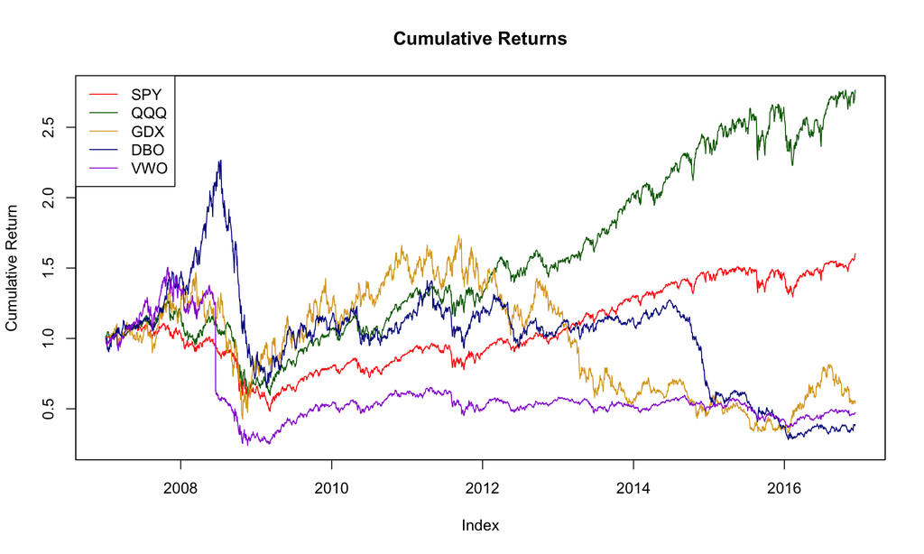

## XTS plot(.)

Not as convenient as the zoo plot - we can no longer input the entire “matrix” object; we must add each series separately in order to layer the plots. - We also need to specify the scale along the vertical axis, as in the xts case, the function will not do this on the fly as it did for us in the zoo case.

Use basket instead of zoo.basket; plot() will know to use the xts version of plot()

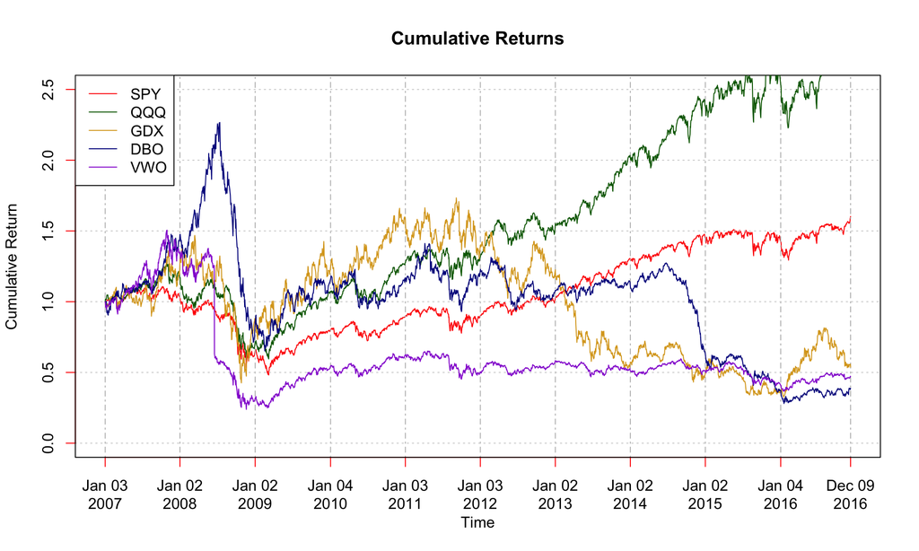

# Plot daily changes

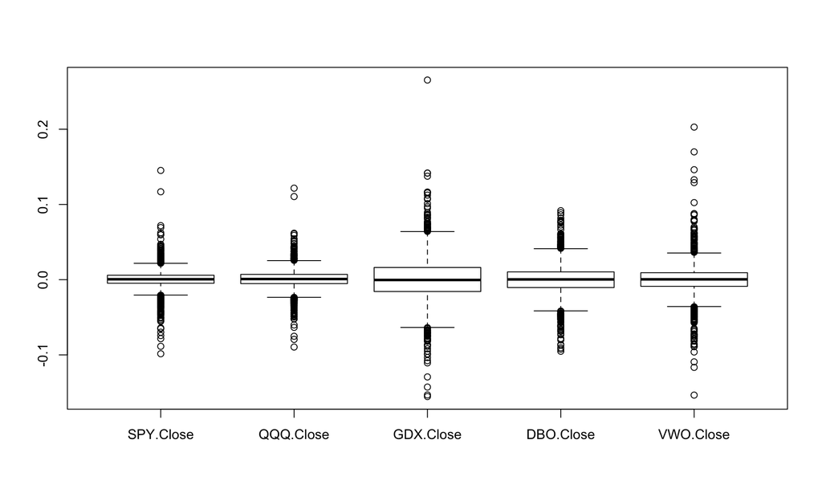

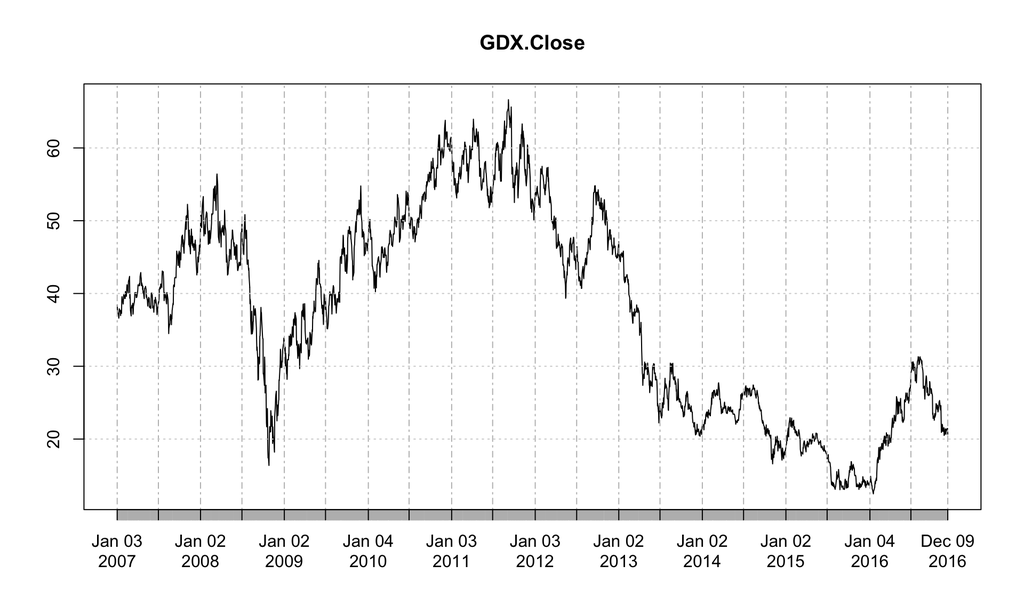

```
## [1] 0.5044202
```

```
##            GDX.Close GDX.Close.1
## 2008-11-21     23.03   0.2653846
```

```
## An 'xts' object on 2007-01-03/2016-12-09 containing:
##   Data: num [1:2504, 1] 77.9 77.1 74.9 75.7 73.9 ...
##  - attr(*, "dimnames")=List of 2
##   ..$ : NULL
##   ..$ : chr "VWO.Close"
##   Indexed by objects of class: [Date] TZ: UTC
##   xts Attributes:
## List of 2
##  $ src    : chr "yahoo"
##  $ updated: POSIXct[1:1], format: "2016-12-10 19:24:51"
```

```
##            GDX.Close
## 2008-11-03     21.01
## 2008-11-04     23.90
## 2008-11-05     23.50
## 2008-11-06     21.93
## 2008-11-07     21.75
## 2008-11-10     23.15
## 2008-11-11     21.64
## 2008-11-12     19.40
## 2008-11-13     21.66
## 2008-11-14     20.55
## 2008-11-17     19.66
## 2008-11-18     19.56
## 2008-11-19     18.61
## 2008-11-20     18.20
## 2008-11-21     23.03
## 2008-11-24     24.63
## 2008-11-25     25.69
## 2008-11-26     26.11
## 2008-11-28     26.57
## 2008-12-01     22.50
## 2008-12-02     24.69
## 2008-12-03     24.06
## 2008-12-04     23.42
## 2008-12-05     23.23
## 2008-12-08     25.26
## 2008-12-09     25.41
## 2008-12-10     28.13
## 2008-12-11     28.02
## 2008-12-12     28.67
## 2008-12-15     30.34
## 2008-12-16     32.34
## 2008-12-17     32.11
## 2008-12-18     29.84
## 2008-12-19     30.58
## 2008-12-22     29.83
## 2008-12-23     30.74
## 2008-12-24     30.59
## 2008-12-26     32.25
## 2008-12-29     33.03
## 2008-12-30     33.00
## 2008-12-31     33.88
```

[output not shown]